# SCN Proteomics MetaboAnalystR Pipeline

Theresa Alexander

2023-08-31

# 1 Load Libraries

These are the packages used in this analysis.

```r
#install instructions found here: https://www.metaboanalyst.ca/docs/RTutorial.xhtml#1.2%20Installation
library("MetaboAnalystR")
library("stringr")
library("dplyr")
library("ggplot2")
library("gplots")
library("xlsx")
library("ggrepel")
library("httr")
library("plyr")
library("gprofiler2")
library("corrplot")
library("RColorBrewer")
library("patchwork")
source("../helper_functions.R")
```

# 2 Load Data and Clean

This metaboanalyst pipeline follows the vignette for data processing, DE, and GSEA. We first initialize an mSet, read in the data, and use the SanityCheckData() function to compute missingness, number of groups, and other sanity checks.

```r
prot_label_mapped <- read.xlsx("datasets/SCN_LFQintensities_withgenenames.xlsx",
                               sheetIndex = 1)
```

```r
mSet<-InitDataObjects("pktable", "stat", FALSE)
```

```
## Starting Rserve:
##  /sw/local/R/4.2/lib/R/bin/R CMD /z1/sw/local/R/4.2/3.16/Rserve/libs//Rserve --no-save
##
## [1] "MetaboAnalyst R objects initialized ..."
```

```r
mSet<-Read.TextData(mSet, "datasets/SCN_LFQintensities.csv", "colu", "disc")
#mSet<-Read.TextData(mSet, "Proteingroups_intensity", "colu", "disc")
mSet<-SanityCheckData(mSet)
```

```
##  [1] "Successfully passed sanity check!"
##  [2] "Samples are not paired."
##  [3] "2 groups were detected in samples."
##  [4] "Only English letters, numbers, underscore, hyphen and forward slash (/) are allowed."
##  [5] "<font color=\"orange\">Other special characters or punctuations (if any) will be stripped off.</font>"
##  [6] "<font color=\"red\">Non-numeric values were found and replaced by NA.</font>"
##  [7] "<font color=\"red\"> 1 features with a constant or single value across samples were found and deleted.</font>"
##  [8] "A total of 2 (0%) missing values were detected."
##  [9] "<u>By default, missing values will be replaced by 1/5 of min positive values of their corresponding variables</u>"
## [10] "Click the <b>Proceed</b> button if you accept the default practice;"
## [11] "Or click the <b>Missing Values</b> button to use other methods."
```

# 3 Normalization and Filtering

```r
mSet<-ReplaceMin(mSet) # impute 0 values to remove missing values with 1/5 of the min positive values for their corresponding samples (MetaboanalsytR's default imputation method)
mSet<- FilterVariable(mSet, "none", "F", 25)
```

```
## [1] " No filtering was applied"
## [1] "  No filtering was applied"
```

```r
mSet<-PreparePrenormData(mSet)
mSet<-Normalization(mSet, rowNorm = "QuantileNorm", "LogNorm", "MeanCenter", ratio=FALSE) #normalize and scale data
mSet<-PlotNormSummary(mSet, "norm_0_", "png", 72, width=NA)
mSet<-PlotSampleNormSummary(mSet, "snorm_0_", "png", 72, width=NA)
```

# 4 PCA calculation and plotting

We will visualize global proteomic similarities/differences by way of PCA and visualize both the PC loadings and scores using ggplot.

```r
mSet<-PCA.Anal(mSet)
mSet<-PlotPCAPairSummary(mSet, "pca_pair_0_", "png", 72, width=NA, 5)
mSet<-PlotPCAScree(mSet, "pca_scree_0_", "png", 72, width=NA, 5)
mSet<-PlotPCA2DScore(mSet, "pca_score2d_0_", "png", 72, width=NA, 1,2,0.95,0,0)
mSet<-PlotPCALoading(mSet, "pca_loading_0_", "png", 72, width=NA, 1,2);
mSet<-PlotPCABiplot(mSet, "pca_biplot_0_", "png", 72, width=NA, 1,2)
mSet<-PlotPCA3DLoading(mSet, "pca_loading3d_0_", "json", 1,2,3)
```

```
## [1] "Annotated data is now ready for PCA 3D visualization!"
```

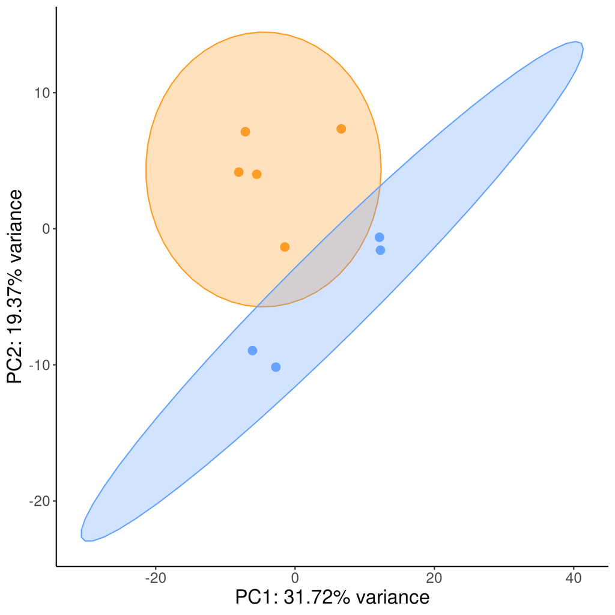

```r
mSet<-PlotPCAPairSummary(mSet, "pca_pair_1_", "png", 72, width=NA, 2)

pca_loadings <- read.csv2(file = "pca_loadings.csv", sep = ",")
pca_score <- read.csv2(file = "pca_score.csv", sep = ",")
pca_score[,-c(1)] <- sapply(pca_score[,-c(1)], as.numeric)
pca_score$Time <- c("P08", "P08", "P08", "P08", "P08", "P21", "P21", "P21", "P21")

#set confidence interval threshold as well as alpha level for plotting the ellipses
ci_95 = .95
alpha = .3

pca <- ggplot(pca_score, aes(x = PC1, y = PC2, col = Time)) +
  geom_point(size = 3) +
  theme_classic() +
  xlab(paste0("PC1: ", round(mSet$analSet$pca$variance[1],4)*100, "% variance")) +
  ylab(paste0("PC2: ", round(mSet$analSet$pca$variance[2],4)*100, "% variance")) +
  #ggtitle("PCA of Normalized Total Protein", subtitle = "CI = 95%") +
  stat_ellipse(mapping = aes(group = Time,
                             fill = Time),
                              geom = "polygon", type = "t", level = ci_95, alpha = alpha) +
  scale_color_manual(values=c("#FF9D27", "#68A3FF"))  +
  scale_fill_manual(values=c("#FF9D27", "#68A3FF")) +
  theme(axis.text=element_text(size=12),
        axis.title=element_text(size=16),
        legend.text=element_text(size=10),
        legend.title = element_text(size=14),
        title = element_text(size=16),
        legend.position = "none")

#setEPS()
#postscript("figures/pcascores_NEW.eps")
pca
```

```r
#dev.off()

mSet$dataSet
```

[output not shown]

[output cut: 3729 more lines]

[output not shown]

Globally, across all the proteins identified and quantified, we see differences between the populations in the P8 vs the P21 samples.

To look into the specific differences between these samples, we will do a differential expression analysis using MetaboanalsytR’s standard pipeline.

# 5 DE

We first compute the fold change between P8 and P21 for each protein, then compute a FDR adjusted p-value for each protein.

```r
mSet <- FC.Anal(mSet, 0, 0)
mSet <- PlotFC(mSet, "fc_0_", "png", 72, width=NA)

mSet <- Ttests.Anal(mSet, threshp = 0.05, paired = FALSE)
```

```
## [1] "Performing regular t-tests ...."
## [1] "A total of 1 significant features were found."
```

```r
mSet <- PlotTT(mSet, "tt_0_", "png", 72, width=NA)
```

Now, we can combine the fold change results and the t-test results to create a volcano plot to visualize the DE results.

```r
prot_label_mapped <- prot_label_mapped %>%
  filter(Protein_ID %in% names(mSet$analSet$tt$p.log))

volc_df <- as.data.frame(cbind("accession_id" = names(mSet$analSet$tt$p.log),
                               "genename" = prot_label_mapped$Gene.Name,
                               "protein_name" = prot_label_mapped$Protein.Name,
                               "adj.p" = mSet$analSet$tt$p.value,
                               "log.adj.p" = mSet$analSet$tt$p.log,
                               "log2_FC" = mSet$analSet$fc$fc.log)) #create data frame which combines all the needed information to plot

volc_df$log.adj.p <- as.numeric(volc_df$log.adj.p)
volc_df$log2_FC <- as.numeric(volc_df$log2_FC)
volc_df$adj.p <- as.numeric(volc_df$adj.p)

volc_df$Significance <- NA
volc_df[volc_df$log2_FC >= 1  & volc_df$adj.p <= .05, ][["Significance"]] <- "P21 Enriched"
volc_df[volc_df$log2_FC <= -1  & volc_df$adj.p <= .05, ][["Significance"]] <- "P08 Enriched"
volc_df[abs(volc_df$log2_FC) < 1 | volc_df$adj.p > .05, "Significance"] <- "Not Enriched"

my_y_lab <- bquote(paste("-Log"[10],"(", italic("p"), ")"))
my_x_lab <- bquote(paste("-Log"[2],"(P21/P8 Fold Change)"))

p <- ggplot(volc_df, aes(x = log2_FC, y = log.adj.p, label = genename)) +
  geom_point(aes(colour = Significance), size = 3) +
  geom_vline(xintercept = c(-1,1)) +
  geom_hline(yintercept = -log10(.05)) +
  theme_classic() +
  labs(x = my_x_lab, y = my_y_lab) +
  theme(legend.position="none") +
  scale_color_manual(values=c('Grey',"#FF9D27", "#68A3FF"))
```

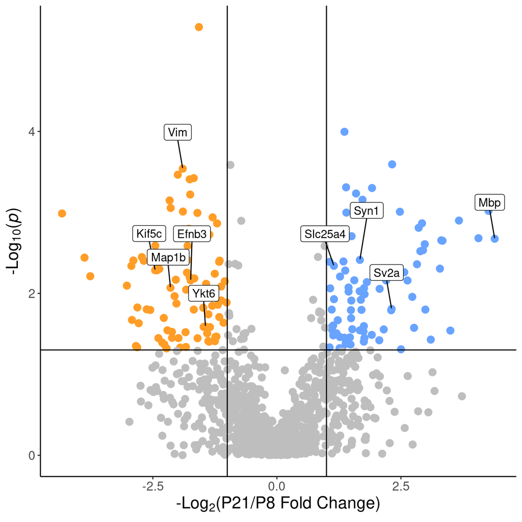

```r
genes <- c("Syn1",
           "Sv2a",
           "Mbp",
           "Ykt6",
           "Vim",
           "Efnb3",
           "Slc25a4",
           "Map1b",
           "Kif5c")

volcano_plot <- p + geom_label_repel(data=filter(volc_df, (genename %in% genes)), nudge_x = -.1,
                     nudge_y = .45, max.overlaps =20) +
  theme(axis.text=element_text(size=12),
        axis.title=element_text(size=16),
        legend.text=element_text(size=14),
        legend.title = element_text(size=20),
        title = element_text(size=16),
        legend.position = "none") +
  guides(colour = guide_legend(override.aes = list(size=6)))


volcano_plot
```

```r
ggsave(volcano_plot, filename = "figures/volcanoplot_NEW.eps", width = 7, height = 7, device = cairo_ps)
```

# 6 PCA Loadings

Adding colors to the PCA plot which correspond to the significant DE proteins.

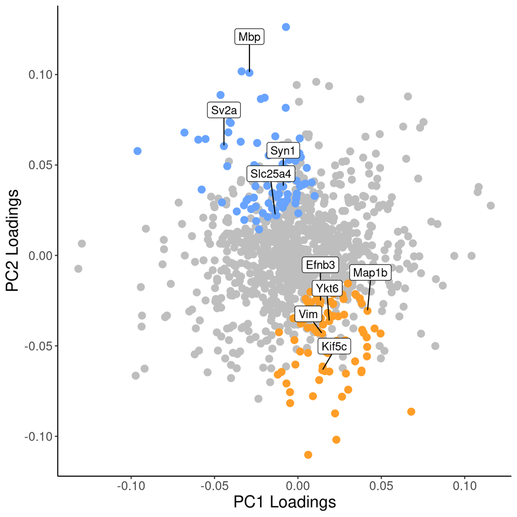

```r
pca_loadings <- as.data.frame(cbind(pca_loadings,
                                    "Significance" = volc_df$Significance,
                                    "accession_id" = names(mSet$analSet$tt$p.log),
                                    "genename" = prot_label_mapped$Gene.Name))
pca_loads_plot <- ggplot(pca_loadings %>% arrange(Significance), aes(x = as.numeric(PC1), y = as.numeric(PC2),
                                                          color = Significance,
                                                          label = genename)) +
  geom_point(size = 3) +
  theme_classic() +
  scale_color_manual(values=c('Grey',"#FF9D27", "#68A3FF"))


pca_loads_plot <- pca_loads_plot  + geom_label_repel(data=filter(pca_loadings, (genename %in% genes)),
                     nudge_y = .02, max.overlaps =20, color = "black") +
  #labs(x = "PC Loadings 1", y = "PC Loadings 2") +
  theme(axis.text=element_text(size=12),
        axis.title=element_text(size=16),
        legend.text=element_text(size=10),
        legend.title = element_text(size=14),
        title = element_text(size=16),
        legend.position = "none") +
  xlab("PC1 Loadings") +
  ylab("PC2 Loadings")

#setEPS()
#postscript("figures/pcaloadings_NEW.eps")
pca_loads_plot
```

```r
#dev.off()
```